# R Notebook

```r
library(here)
library(readxl)
#library(papeR)
#library(outliers)
library(kableExtra)
#library(DataExplorer)
library(lubridate)
library(forecast)
library(nlme)
#library(nortest)
library(tidyverse)
library(ggfortify)
```

```r
library(dygraphs)
library(seasonal)
library(seasonalview)
```

Rutas

```r
raw_data <- here("data", "raw")
interim_data <- here("data", "interim")
final_data <- here("data", "processed")
modelos <- here('models')
```

Leyendo base de datos

```r
base <- read_excel(paste0(raw_data,"/Base Datos.xlsx"),
    col_types = c("text", "numeric", "numeric"))

head(base)
```

| Activo neto | CRC | USD |
| --- | --- | --- |
| 2001-02 | 12637.44 | 21.8817 |
| 2001-03 | 13569.26 | 24.1889 |
| 2001-04 | 11895.00 | 24.6323 |
| 2001-05 | 12882.29 | 30.7223 |
| 2001-06 | 13393.90 | 30.6749 |
| 2001-07 | 11067.66 | 31.9302 |

Extrayendo la base de colones y de dolares

```r
colones <- data_frame(date = base$`Activo neto`,
                  col =  as.double(base$CRC)) %>%
  mutate(date = ymd(paste0(date, "-01"))) %>%
  mutate(year = as.factor(year(date)),
         month = as.factor(month(date)))
head(colones)
```

| date | col | year | month |
| --- | --- | --- | --- |
| 2001-02-01 | 12637.44 | 2001 | 2 |
| 2001-03-01 | 13569.26 | 2001 | 3 |
| 2001-04-01 | 11895.00 | 2001 | 4 |
| 2001-05-01 | 12882.29 | 2001 | 5 |
| 2001-06-01 | 13393.90 | 2001 | 6 |
| 2001-07-01 | 11067.66 | 2001 | 7 |

Convirtiendo los datos a series de tiempo

```r
# Colones

# 6 periodos para utilizar a modo de validación
colones_val <- colones %>%
  slice_tail(n = 6)

# Serie completa para el analisis exploratorio
colones_full <- colones

# 10 años de datos para modelar
colones <- colones %>%
  filter(date>"2007-12-01" & date<="2020-01-01")

# Objetos ts tanto para la serie completa como para la serie de modelado
colones_ts_full <- ts(colones_full$col, start = c(2001,2), frequency = 12)
colones_ts <- ts(colones$col, start = c(2008,1), frequency = 12)
colones_ts_val <- tail(colones_ts_full, 6)
```

## 2.3 - Método de Holt - Winters (Multiplicativo)

Debido a que la serie de colones posee tendecia-ciclo, estacionalidad y patrón irregular se procede a analizar primero a travez del modelo de suavizamiento exponencial de Holt-Winters.

```r
APaditivo.hw <- HoltWinters (colones_ts, seasonal = "multiplicative")
APaditivo.hw ; APaditivo.hw$SSE
```

```
## Holt-Winters exponential smoothing with trend and multiplicative seasonal component.
##
## Call:
## HoltWinters(x = colones_ts, seasonal = "multiplicative")
##
## Smoothing parameters:
##  alpha: 0.6432368
##  beta : 0
##  gamma: 1
##
## Coefficients:
##             [,1]
## a   8.685805e+05
## b   2.015759e+03
## s1  9.710040e-01
## s2  1.043035e+00
## s3  1.026594e+00
## s4  1.014302e+00
## s5  1.056782e+00
## s6  1.064520e+00
## s7  1.014535e+00
## s8  1.067233e+00
## s9  1.004247e+00
## s10 9.618488e-01
## s11 9.005550e-01
## s12 1.024179e+00
```

```
## [1] 212553467675
```

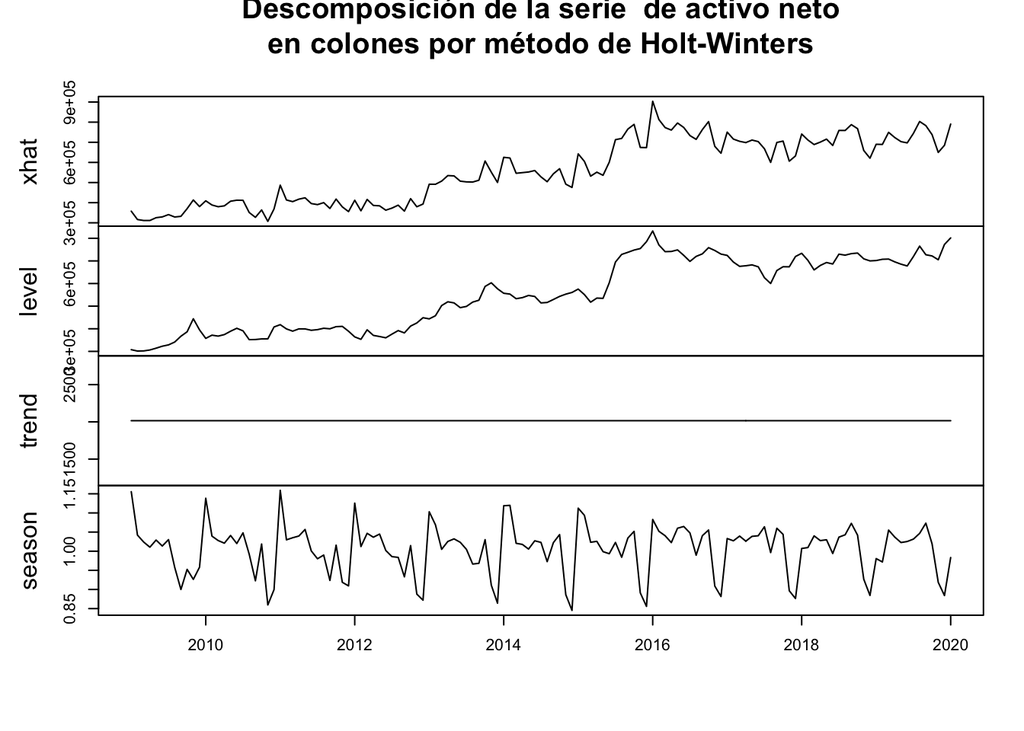

```r
#descomposici?n de la serie
plot (APaditivo.hw$fitted, main = "Descomposición de la serie  de activo neto\nen colones por método de Holt-Winters", xlab = "")
```

```r
#PRON?STICO aditivo
AP.predict <- predict(APaditivo.hw, n.ahead = 6,seasonal = "multiplicative")

AP.predict2 <-forecast(APaditivo.hw)

pred_HW<- ts(c(AP.predict2$fitted, window(ts(AP.predict2$mean), start=1, end=6)),
   start = start(AP.predict2$fitted),
   frequency = frequency(AP.predict2$fitted))

HW_preds<- cbind(Serie = colones_ts, Real = colones_ts_val,Prediccion1=pred_HW)



# Graficos
dygraph(HW_preds, main = "Predicción modelo Holt-Winters") %>%
dySeries("Serie", label = "Entrenamiento") %>%
dySeries("Real", label = "Prueba") %>%
dySeries("Prediccion1", label = "Predicción") %>%
dyAxis("x", label = "Periodo") %>%
dyAxis("y", label = "Montos (COL)") %>%
dyOptions(maxNumberWidth = 20, colors = RColorBrewer::brewer.pal(3, "Set1")) %>%
dyRangeSelector()
```

[interactive chart not shown]

```r
acc_hotlWint <- tibble( Metodo = c("Serie de entrenamiento",
                   "Serie de prueba"),
        RMSE = round(c(forecast::accuracy(AP.predict2, colones_ts_val)[,2]),3),
        MAE = round(c(forecast::accuracy(AP.predict2, colones_ts_val)[,3]),3),
        MAPE = round(c(forecast::accuracy(AP.predict2, colones_ts_val)[,5]),3),

        )

acc_hotlWint %>%
  mutate_if(is.numeric, function(x) {
    cell_spec(x, bold = T,
              color = spec_color(x, end = 0.9, direction = -1),
              font_size = spec_font_size(x, begin = 12,end = 14, scale_from = NA))
  }) %>%
  kable(escape = F, caption = "Medidas de ajuste (Holt-Winters)", digits = 2) %>%
  kable_styling(bootstrap_options = c("striped", "hover", "condensed", "responsive"))
```

Medidas de ajuste (Holt-Winters)

| Metodo | RMSE | MAE | MAPE |
| --- | --- | --- | --- |
| Serie de entrenamiento | 39976.823 | 29506.247 | 5.361 |
| Serie de prueba | 104977.756 | 84734.951 | 10.338 |

# 3 - Modelos

## 3.1 Modelos de regresión para series de tiempo univariadas

### 3.1.1 - Modelo de regresión regular

Al existir evidente tendencia y estacionalidad en la serie, se modela usando variables dummy para modelar los factores estacionales.

Primer modelo de regresón simple para graficar la linea de tendencia.

```r
x<-time(colones_ts)
Seas <- cycle(colones_ts)

model1=lm(colones_ts~x++ factor(Seas))
summary(model1)
```

```
##
## Call:
## lm(formula = colones_ts ~ x + +factor(Seas))
##
## Residuals:
##     Min      1Q  Median      3Q     Max
## -105963  -42510   -5299   24495  167379
##
## Coefficients:
##                 Estimate Std. Error t value Pr(>|t|)
## (Intercept)    -87737818    3152066 -27.835  < 2e-16 ***
## x                  43848       1565  28.017  < 2e-16 ***
## factor(Seas)2     -25395      26255  -0.967 0.335189
## factor(Seas)3     -23477      26252  -0.894 0.372796
## factor(Seas)4     -25628      26250  -0.976 0.330698
## factor(Seas)5     -26770      26248  -1.020 0.309647
## factor(Seas)6     -31231      26247  -1.190 0.236223
## factor(Seas)7     -22895      26247  -0.872 0.384635
## factor(Seas)8     -37586      26247  -1.432 0.154506
## factor(Seas)9     -15000      26248  -0.571 0.568651
## factor(Seas)10     -9652      26250  -0.368 0.713680
## factor(Seas)11    -71605      26252  -2.728 0.007248 **
## factor(Seas)12    -89188      26255  -3.397 0.000901 ***
## ---
## Signif. codes:  0 '***' 0.001 '**' 0.01 '*' 0.05 '.' 0.1 ' ' 1
##
## Residual standard error: 65560 on 132 degrees of freedom
## Multiple R-squared:  0.8583, Adjusted R-squared:  0.8454
## F-statistic: 66.63 on 12 and 132 DF,  p-value: < 2.2e-16
```

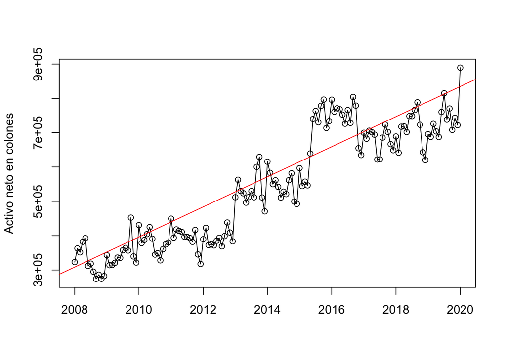

```r
plot(colones_ts,type='o',main='', xlab = "", ylab = "Activo neto en colones")
abline(model1, col="red")
```

#### 3.1.1.1 - Analisis de los residuos

##### 3.1.1.1.1 Normalidad

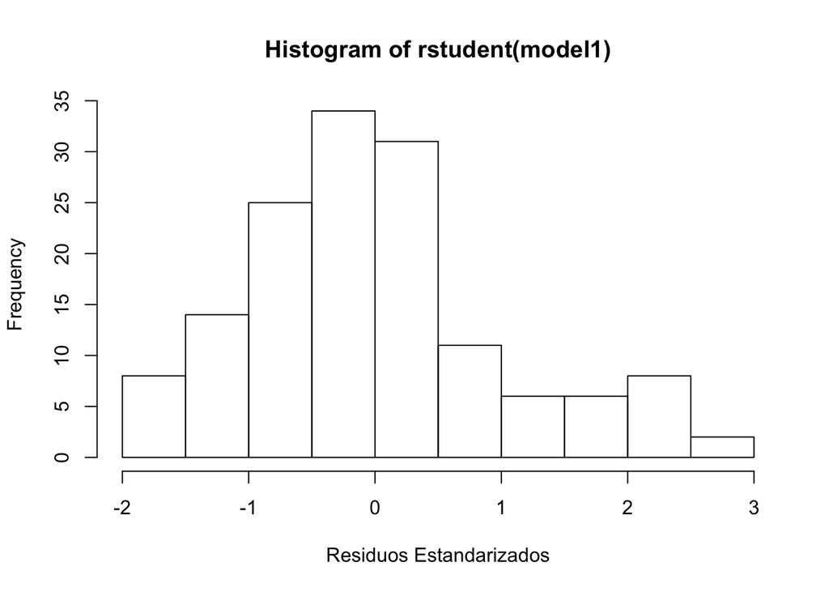

```r
#Normalidad Ho: La muestra proviene de una distribuci?n normal
#An?lisis gr?fico
hist(rstudent(model1),xlab='Residuos Estandarizados')
```

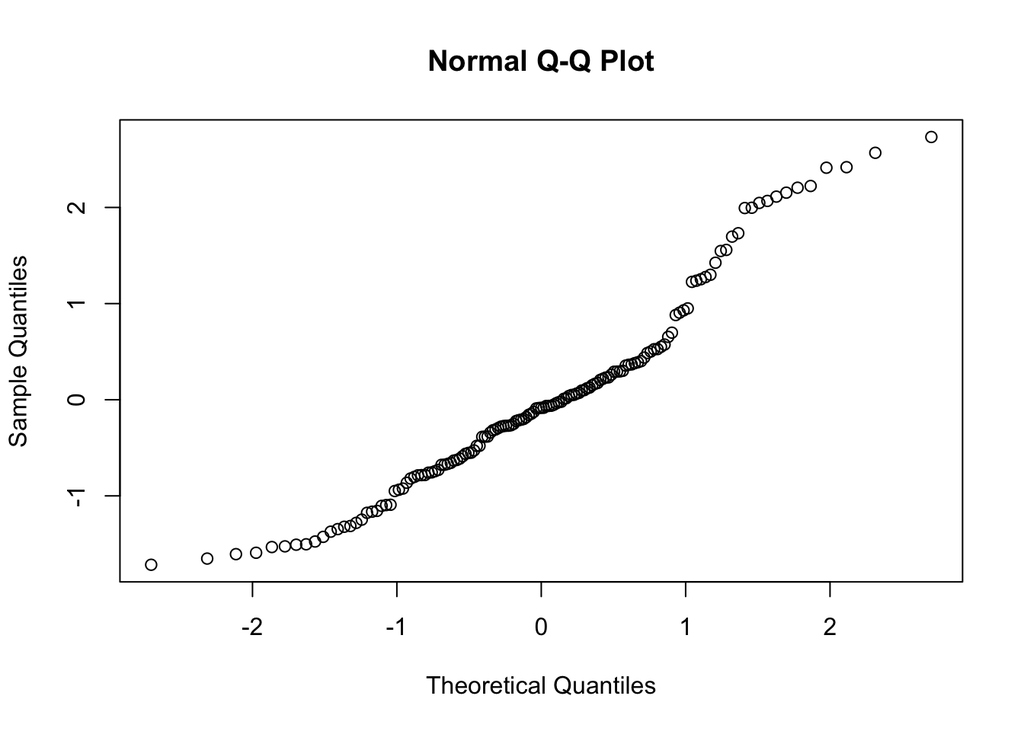

```r
qqnorm(rstudent(model1))
```

```r
#An?lisis formal
normtest::jb.norm.test(model1$residuals) #Prueba de Jarque Bera
```

```
##
##  Jarque-Bera test for normality
##
## data:  model1$residuals
## JB = 11.368, p-value = 0.0105
```

```r
normtest::frosini.norm.test(model1$residuals) #Prueba de Frosini
```

```
##
##  Frosini test for normality
##
## data:  model1$residuals
## B = 0.43704, p-value = 5e-04
```

```r
normtest::geary.norm.test(model1$residuals) #Prueba de Geary
```

```
##
##  Geary test for normality
##
## data:  model1$residuals
## d = 0.76178, p-value = 0.9785
```

En el análisis de los residuos, en primer lugar, se intenta probar que estos tengan una distribución normal. Para esto se realizaron los gráficos de histograma y de qqnorm en donde hay indicios de que la distribución es normal pero tiene una cola pesada a la derecha. Para completar el análisis se prueba de manera formal la hipótesis de que los residuos se distribuyen normalmente mediante 3 pruebas: Jarque-Bera, Frosini y Geary. Para todas, la hipótesis nula es que la muestra se distribuye normalmente y 2 de ellas se rechazaron con un nivel de significancia del 95%, por lo tanto, se concluye que los residuos de la regresión lineal No se distribuyen normalmente.

##### 3.1.1.1.2 - Heterocedasticidad

```r
#Heterocedasticidad Ho: Los residuos son homocedasticos (varianza constante)
lmtest::bptest(model1)
```

```
##
##  studentized Breusch-Pagan test
##
## data:  model1
## BP = 9.4624, df = 12, p-value = 0.663
```

Además, se comprueba la heterocedasticidad de los residuos a travéz del test de Breusch-Pagan en la cual la hipótesis nula es que los residuos son homocedasticos y con un nivel de significancia del 95% no se rechaza, por ende, se puede afirmar que la varianza de los residuos es constante.

##### 3.1.1.1.3 Autocorrelación

```r
#Hip?tesis nula Ho: No hay autocorrelaci?n de los errores
#Breusch Godfrey
lmtest::bgtest(model1)
```

```
##
##  Breusch-Godfrey test for serial correlation of order up to 1
##
## data:  model1
## LM test = 101.95, df = 1, p-value < 2.2e-16
```

```r
#Durbin Watson (Si R2 < d, entonces la regresi?n podr?a no ser espuria, un d muy bajo es sospecha y deber?a llamar la atenci?n)
lmtest::dwtest(model1)
```

```
##
##  Durbin-Watson test
##
## data:  model1
## DW = 0.32227, p-value < 2.2e-16
## alternative hypothesis: true autocorrelation is greater than 0
```

```r
#Box.test(residuals(consump1), type = "Ljung-Box")
Box.test(residuals(model1), type = "Ljung-Box")
```

```
##
##  Box-Ljung test
##
## data:  residuals(model1)
## X-squared = 103.46, df = 1, p-value < 2.2e-16
```

Finalmente, se prueba el supuesto de autocorrelación de los errores mediante 3 pruebas de hipótesis. Se realiza la prueba Breusch-Godfrey para correlaciones seriales de orden 1, la prueba de Durbin-Watson y la prueba de Box-Ljung. Para las 3, la hipótesis nula es que no hay autocorrelación en los errores y dado que todas se rechazan con un nivel de signficancia del 95% se concluye que existe autocorrelación en los residuos de la regresión.

Como esto representa un problema, se procede a realizar una diferenciación a la serie para corregir autocorrelación y poder estimar la regresión lineal nuevamente. Esto se realiza mediante modelos de ARIMA.

## 3.2 - Modelos ARIMA

### 3.2.1 - Identificación

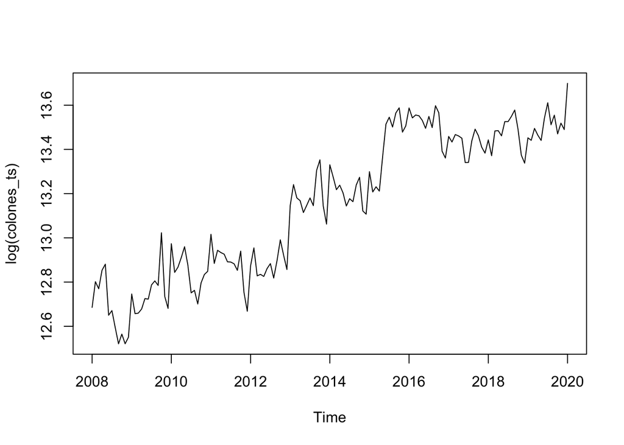

```r
#plot.ts(colones_ts)
#plot(diff(colones_ts))
plot(log(colones_ts))
```

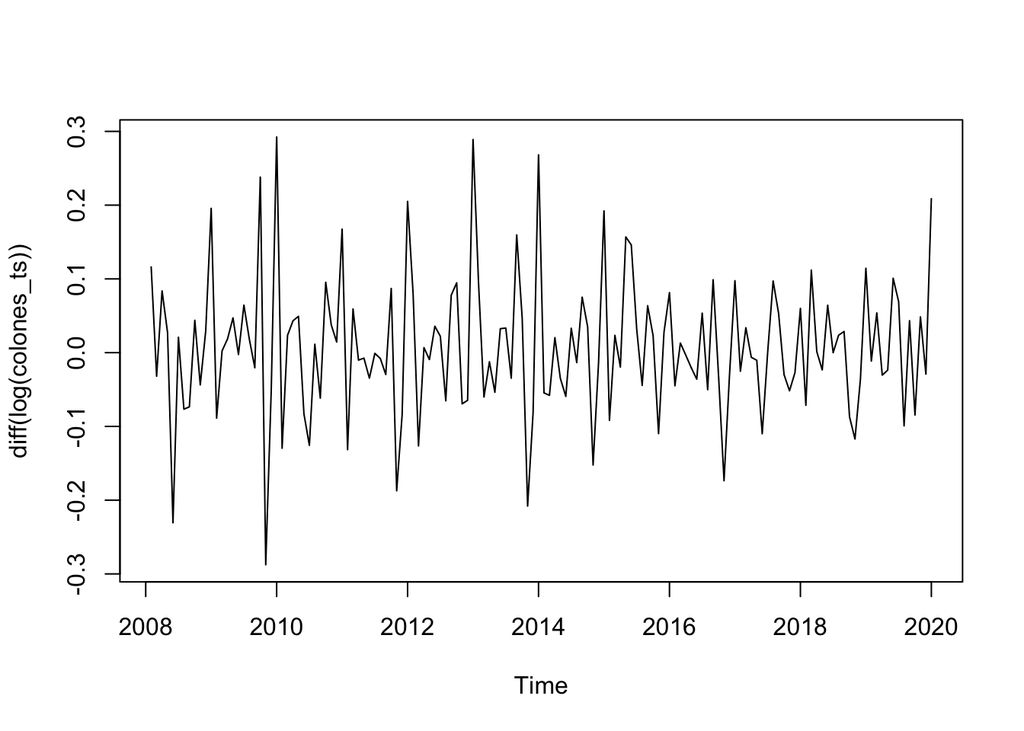

```r
plot(diff(log(colones_ts)))
```

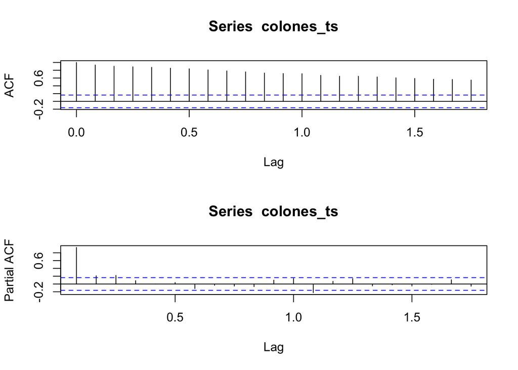

```r
layout(1:2)
acf(colones_ts)
pacf(colones_ts)
```

*Prueba formal*

```r
#Prueba formal de Dick-Fuller para analizar la raiz unitaria, random walk o no estacionariedad, Ho:La serie tiene raiz unitaria
tseries::adf.test(colones_ts)
```

```
##
##  Augmented Dickey-Fuller Test
##
## data:  colones_ts
## Dickey-Fuller = -2.5311, Lag order = 5, p-value = 0.3553
## alternative hypothesis: stationary
```

Debido a la tendencia de la serie y la irregularidad en los gráficos de función de autcorrelación y de autocorrelación parcial se puede determinar que la serie no es estacionaria, además, basado en la prueba formal de Dickey-Fuller se observa que no se rechaza de que la serie tiene raiz unitaria o en otras palabras que es no estacionaria. Entonces se procede a diferenciar la serie y aplicarle logaritmo natural para tratar de hacerla estacionaria, es decir con media y varianza constante en el tiempo.

*Diferenciacion y logaritmo*

```r
dygraph(diff(log(colones_ts)),main="Activo neto en colones - Primera diferencia y Logaritmo",ylab='Dif(log(y))',xlab="Periodo") %>% dyRangeSelector()
```

[interactive chart not shown]

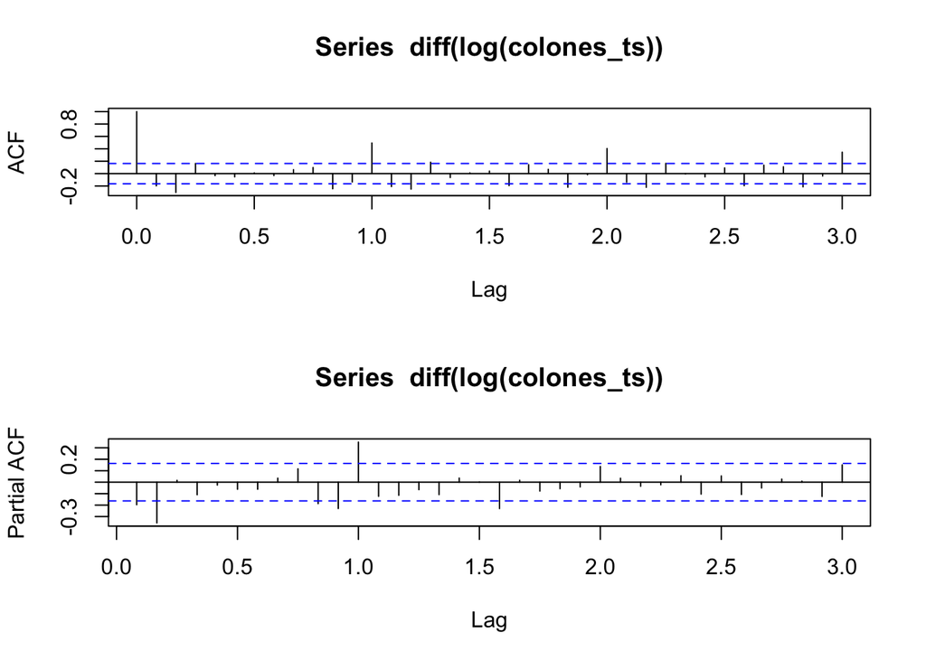

```r
layout(1:2)
acf(diff(log(colones_ts)), lag.max = 36)
pacf(diff(log(colones_ts)), lag.max = 36)
```

*Prueba formal*

```r
#Prueba formal de Dick-Fuller para analizar la raiz unitaria, random walk o no estacionariedad, Ho:La serie tiene raiz unitaria
tseries::adf.test(diff(log(colones_ts)))
```

```
##
##  Augmented Dickey-Fuller Test
##
## data:  diff(log(colones_ts))
## Dickey-Fuller = -5.9197, Lag order = 5, p-value = 0.01
## alternative hypothesis: stationary
```

Al ver el gráfico de la serie, que la media es constante y la variancia está al rededor de 0 y apoyado en la prueba de hipótesis del test de Dickey-Fuller se puede concluir que la serie con logaritmo y diferenciada una vez es estacionaria.

#### 3.2.1.2 - Modelo 2 (I1 - sMA1)

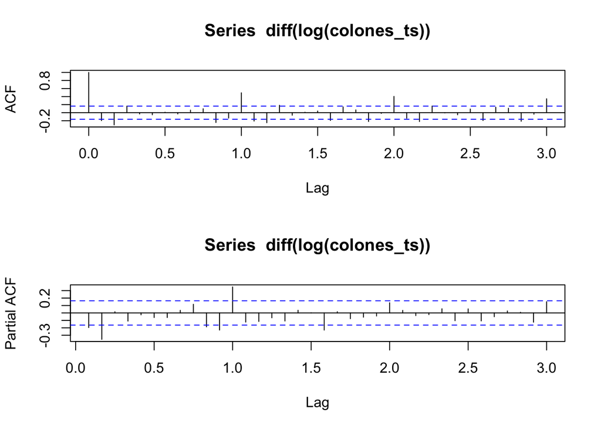

```r
layout(1:2)
acf(diff(log(colones_ts)), lag.max = 36)
pacf(diff(log(colones_ts)), lag.max = 36)
```

Al observar las estacas de parte estacional (cada 12 periodos) se observa que en el ACF van cayendo a 0 de forma pausada y en el PACF, en cambio, no es tan claro que las estacas vayan cayendo suavemente. Tomando encuenta lo anterior, se procede con un modelo MA1 en la parte estacional.

```r
#MODELO 2

colones_tsn<-log(colones_ts)

mod1<-arima(colones_tsn, method="ML",order = c(0,1,0), seasonal = c(0,0,1))
mod1
```

```
##
## Call:
## arima(x = colones_tsn, order = c(0, 1, 0), seasonal = c(0, 0, 1), method = "ML")
##
## Coefficients:
##         sma1
##       0.3897
## s.e.  0.0693
##
## sigma^2 estimated as 0.007199:  log likelihood = 149.91,  aic = -295.83
```

```r
#mod2$coef

#Intervalo de confianza para el coeficiente
confint(mod1)
```

```
##          2.5 %    97.5 %
## sma1 0.2537836 0.5255794
```

En este modelo se observa que el coeficiente en valor absoluto es menor que 1 y que el intervalo de confianza a un 95% no contiene al 1 por lo que se puede decir el coeficiente es estadisticamente distinto de 1.

*Normalidad de los residuos*

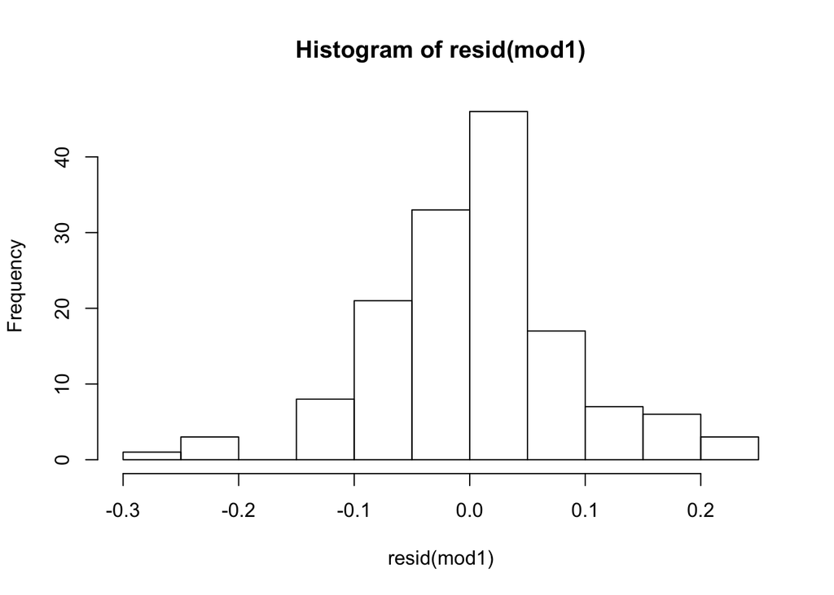

```r
#JARQUE-BERA (Ho: LOS RESIDUOS SE DISTRIBUYEN NORMALMENTE)
hist(resid(mod1))
```

```r
tseries::jarque.bera.test(resid(mod1))
```

```
##
##  Jarque Bera Test
##
## data:  resid(mod1)
## X-squared = 9.3426, df = 2, p-value = 0.00936
```

*Independencia de los residuos*

```r
#Ho: LOS RESIDUOS EN SU CONJUNTO SON INDEPENDIENTES
Box.test(resid(mod1), lag = 1, type = "Ljung")
```

```
##
##  Box-Ljung test
##
## data:  resid(mod1)
## X-squared = 1.9789, df = 1, p-value = 0.1595
```

Además, la prueba de Box-Ljung arroja que no se rechaza la hipótesis de que los residuos sean independientes, es decir, estos no estan correlacionados.

*Funciones de autocorrelación de los residuos*

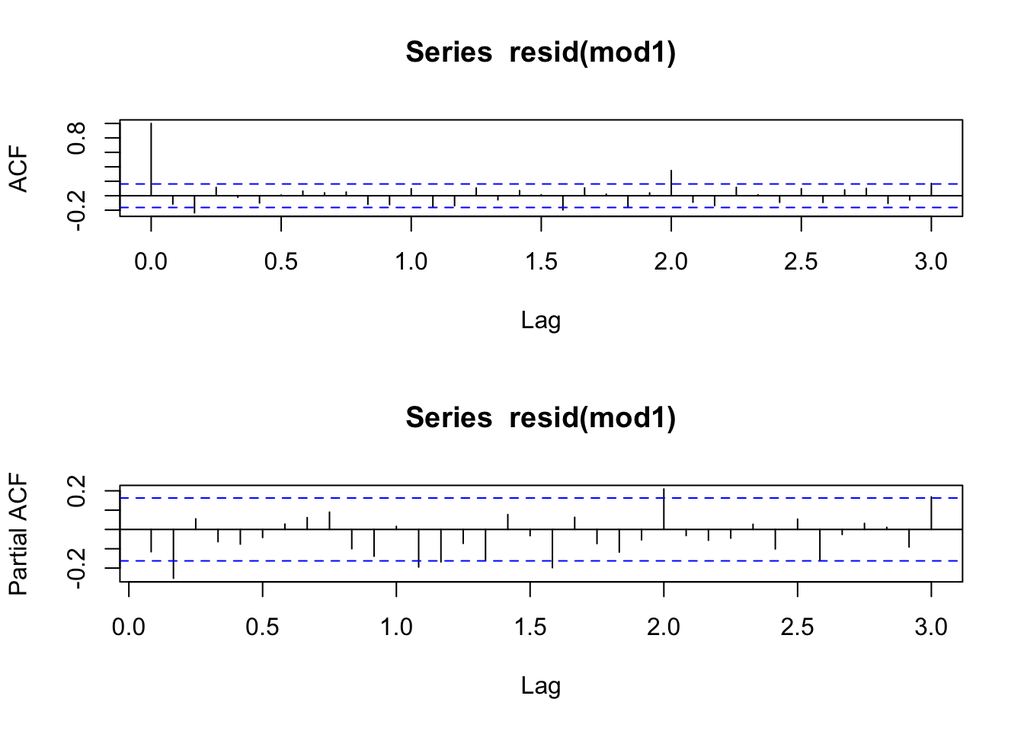

```r
layout(1:2)
acf(resid(mod1), lag.max = 36)
pacf(resid(mod1), lag.max = 36)
```

```r
#MODELO 3
mod3<-arima(colones_tsn, method="ML",order = c(0,1,0), seasonal = list(order = c(0,1,1)))
mod3
```

```
##
## Call:
## arima(x = colones_tsn, order = c(0, 1, 0), seasonal = list(order = c(0, 1, 1)),
##     method = "ML")
##
## Coefficients:
##          sma1
##       -0.6771
## s.e.   0.0827
##
## sigma^2 estimated as 0.005704:  log likelihood = 150.02,  aic = -296.04
```

```r
#mod2$coef

#Intervalo de confianza para el coeficiente
confint(mod3)
```

```
##           2.5 %     97.5 %
## sma1 -0.8391834 -0.5150501
```

*Normalidad de los residuos*

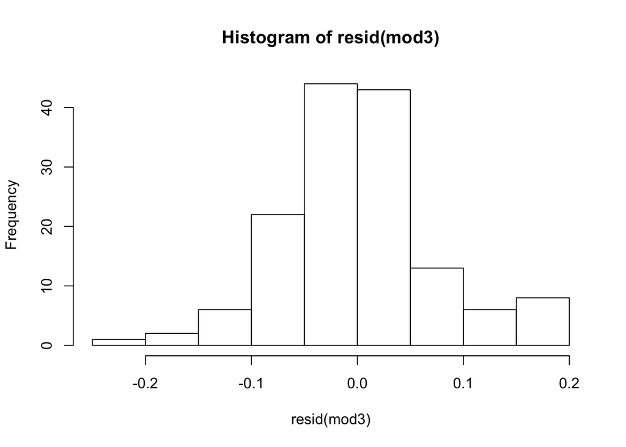

```r
#JARQUE-BERA (Ho: LOS RESIDUOS SE DISTRIBUYEN NORMALMENTE)
hist(resid(mod3))
```

```r
tseries::jarque.bera.test(resid(mod3))
```

```
##
##  Jarque Bera Test
##
## data:  resid(mod3)
## X-squared = 5.6162, df = 2, p-value = 0.06032
```

Con base en el histograma se aprecia que los errores se distribuyen aproximadamente normales y la prueba de normalidad de Jarque-Bera afirma esto.

*Independencia de los residuos*

```r
#Ho: LOS RESIDUOS EN SU CONJUNTO SON INDEPENDIENTES
Box.test (resid(mod3), lag = 1, type = "Ljung")
```

```
##
##  Box-Ljung test
##
## data:  resid(mod3)
## X-squared = 0.81746, df = 1, p-value = 0.3659
```

Además, la prueba de Box-Ljung arroja que no se rechaza la hipótesis de que los residuos sean independientes, es decir, estos no estan correlacionados.

*Funciones de autocorrelación de los residuos*

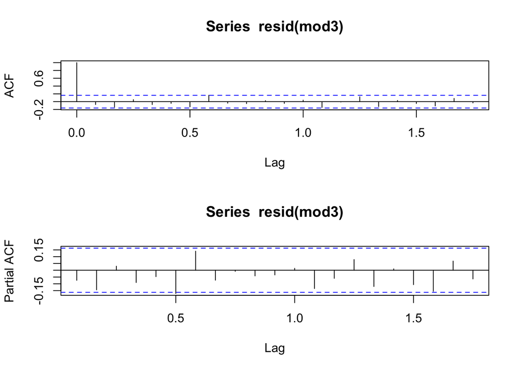

```r
layout(1:2)
acf(resid(mod3))
pacf(resid(mod3))
```

En los gráficos de funciones de autocorrelación, se aprecia que aún hay bastones que sobrepasan los intervalos. Por esta razón se procede a probar los modelos con base en los indicadores de ajuste con respecto a la serie y al pronóstico de 6 periodos contra el modelo propuesto por el auto arima x13.

#### 3.2.1.5 - Auto ARIMA - X13-ARIMA-SEATS

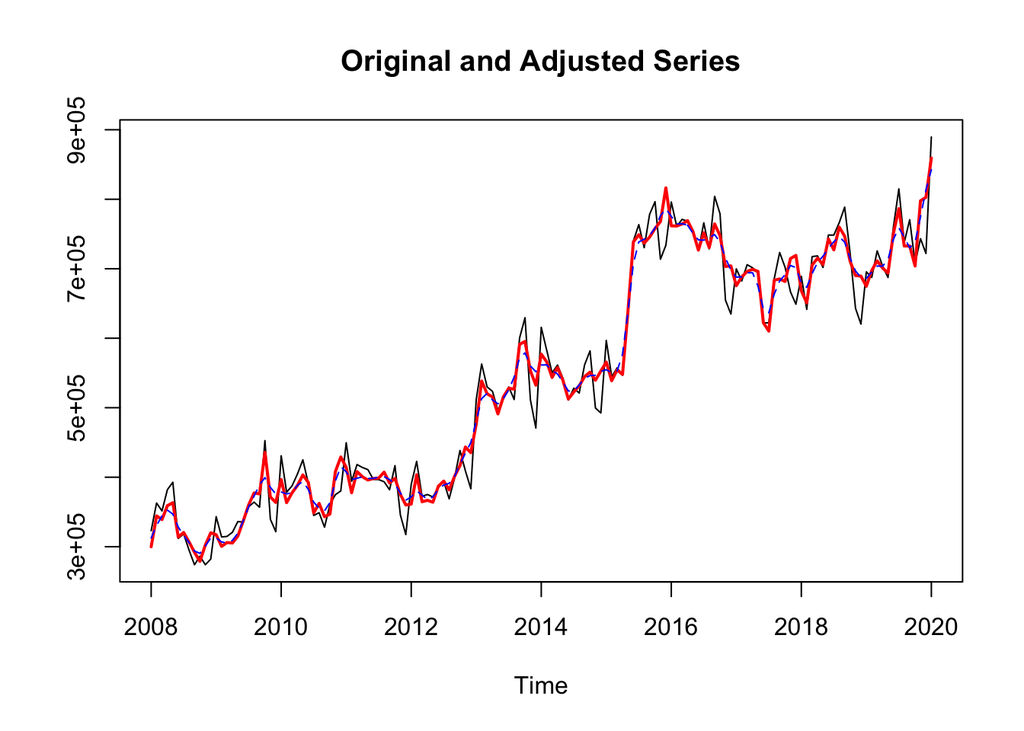

```r
m<-seas(
x = colones_ts,
transform.function = "log",
regression.aictest = NULL,
outlier = NULL
)

#grafico ajustado
plot(m, trend = TRUE)
```

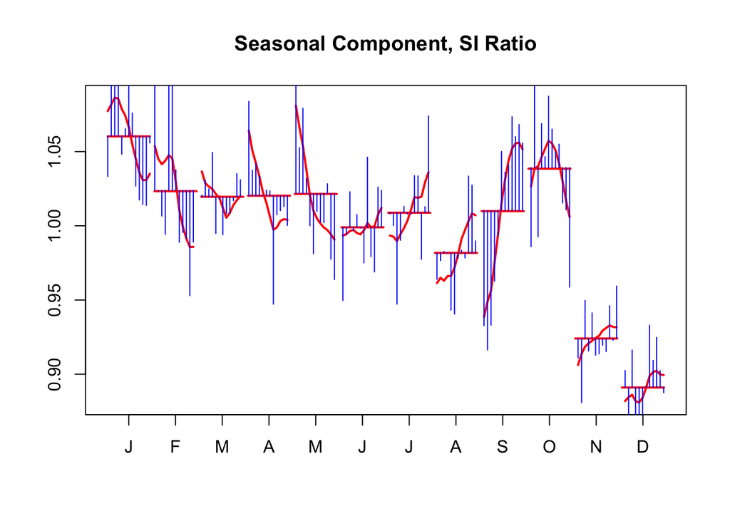

```r
monthplot(m)
```

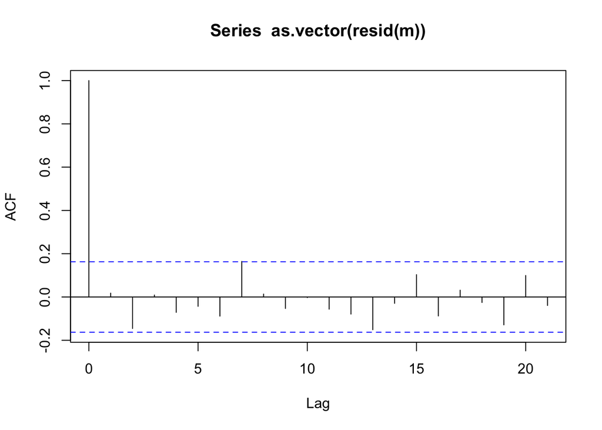

```r
acf(as.vector(resid(m)))
```

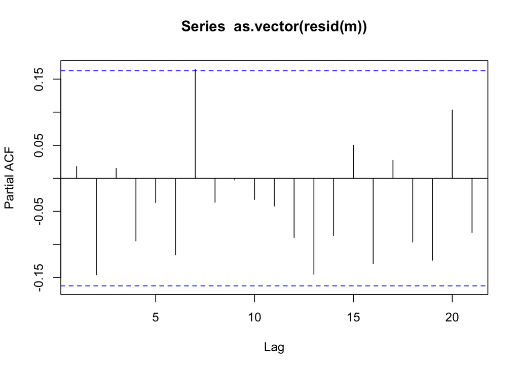

```r
pacf(as.vector(resid(m)))
```

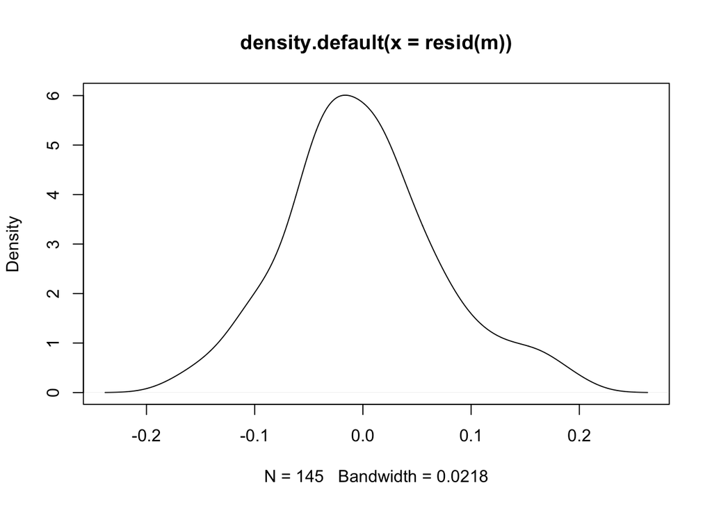

```r
plot(density(resid(m)))
```

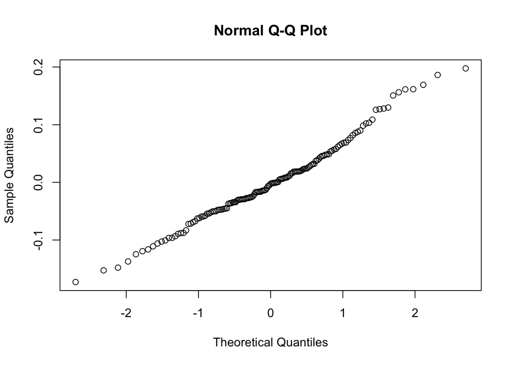

```r
qqnorm(resid(m))
```

Automatic ARIMA Model Selection Procedure based closely on TRAMO ,method of Gomez and Maravall (2000) “Automatic Modeling Methods for Univariate Series”, A Course in Time Series (Edited by D. Pena, G. C. Tiao, R. S. Tsay), New York : J. Wiley and Sons

Maximum order for regular ARMA parameters : 2

Maximum order for seasonal ARMA parameters : 1

Maximum order for regular differencing : 2

Maximum order for seasonal differencing : 1

Results of Unit Root Test for identifying orders of differencing:

Regular difference order : 1 Seasonal difference order : 1

Mean is not significant.

Best Five ARIMA Models

Model # 1 : (0 1 0)(0 1 1) (BIC2 = -2.199) Model # 2 : (1 1 1)(0 1 1) (BIC2 = -2.176) Model # 3 : (0 1 1)(0 1 1) (BIC2 = -2.173) Model # 4 : (1 1 0)(0 1 1) (BIC2 = -2.169) Model # 5 : (0 1 2)(0 1 1) (BIC2 = -2.165) Preliminary model choice : (0 1 0)(0 1 1)

Model changed to ( 0, 1, 1) ( 0, 1, 1)

Final Checks for Identified Model

Checking for Unit Roots.

No unit root found.

Checking for nonseasonal overdifferencing.

Nonseasonal MA not within 0.001 of 1.0 - model passes test.

Checking for insignificant ARMA coefficients.

Final automatic model choice : (0 1 1)(0 1 1)

End of automatic model selection procedure.

Average absolute percentage error in within-sample forecasts:

Last year: 7.39 Last-1 year: 5.83 Last-2 year: 4.76 Last three years: 6.00

Estimation converged in 1 ARMA iterations, 4 function evaluations.

De la salida del X13-ARIMA-SEATS se extrae que algunos de los modelos analizados fueron probados tambien en el proceso automatico y que el modelo seleccionado no coincide con el modelo que recomiendo el autoarima. Entonces, se procede a probar los modelos propuestos contra el modelo autorima.

```r
mod4<-arima(colones_tsn, method="ML",order = c(0,1,1), seasonal = list(order = c(0,1,1)))
mod4
```

```
##
## Call:
## arima(x = colones_tsn, order = c(0, 1, 1), seasonal = list(order = c(0, 1, 1)),
##     method = "ML")
##
## Coefficients:
##           ma1     sma1
##       -0.1290  -0.6950
## s.e.   0.1079   0.0837
##
## sigma^2 estimated as 0.005619:  log likelihood = 150.72,  aic = -295.43
```

```r
#Intervalo de confianza para el coeficiente
confint(mod4)
```

```
##           2.5 %      97.5 %
## ma1  -0.3405078  0.08254998
## sma1 -0.8590943 -0.53087932
```

*Normalidad de los residuos*

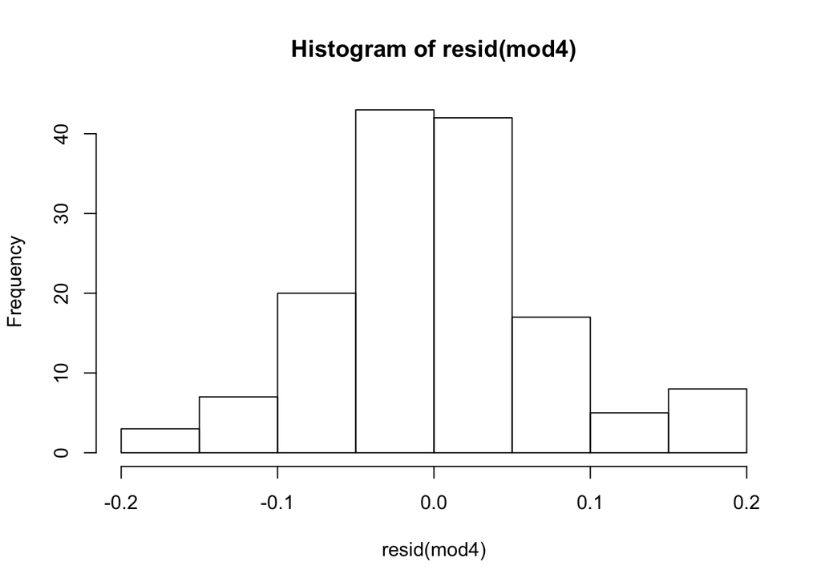

```r
#JARQUE-BERA (Ho: LOS RESIDUOS SE DISTRIBUYEN NORMALMENTE)
hist(resid(mod4))
```

```r
tseries::jarque.bera.test(resid(mod4))
```

```
##
##  Jarque Bera Test
##
## data:  resid(mod4)
## X-squared = 5.9416, df = 2, p-value = 0.05126
```

Con base en el histograma se aprecia que los errores se distribuyen aproximadamente normales y la prueba de normalidad de Jarque-Bera confirma esa apreciación.

*Independencia de los residuos*

```r
#Ho: LOS RESIDUOS EN SU CONJUNTO SON INDEPENDIENTES
Box.test (resid(mod4), lag = 1, type = "Ljung")
```

```
##
##  Box-Ljung test
##
## data:  resid(mod4)
## X-squared = 0.12753, df = 1, p-value = 0.721
```

Además, la prueba de Box-Ljung arroja que no se rechaza la hipótesis de que los residuos sean independientes, es decir, estos no estan correlacionados.

*Funciones de autocorrelación de los residuos*

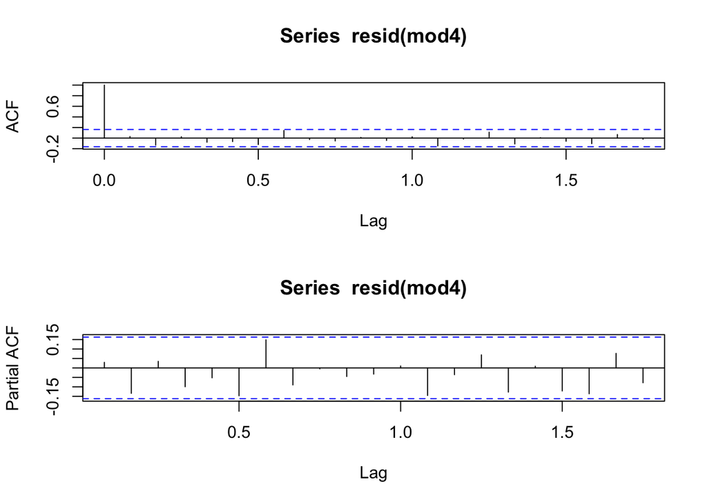

```r
layout(1:2)
acf(resid(mod4))
pacf(resid(mod4))
```

# 4 - Selección del mejor modelo

Una vez teniendo los modelos de Holt-Winters, de regresión y Box-Jenkings (ARIMA) se procede a compararlos en términos de ajuste visual y de indicadores de ajuste para determinar cual es el mejor modelo que pronostique el áctivo neto en colones.

```r
f_mod1 <- forecast(colones_ts, h = 6, model = mod3)
arima1_ts_f = ts(
  f_mod1$mean,
  frequency = 12,
  start = c(2020, 2),
  end = c(2020, 7)
)

f_mod2 <- forecast(colones_ts, h = 6, model = mod4)
arima2_ts_f = ts(
  f_mod2$mean,
  frequency = 12,
  start = c(2020, 2),
  end = c(2020, 7)
)


todos_preds <- cbind(
  Serie = colones_ts,
  Real = colones_ts_val,
  #Prediccion1=fit_ses1$mean,
  #Prediccion2=ts(window(ts(fit_holt$mean), start=1, end=6),frequency = 12, start = c(2018,7)),
  Prediccion1 = ts(
    window(ts(AP.predict2$mean), start = 1, end = 6),
    frequency = 12,
    start = c(2020, 2)
  ),
  #Prediccion4=mod1.1_ts_f,
  Prediccion2 = arima1_ts_f,
  Prediccion3 = arima2_ts_f
)

# Graficamos
dygraph(todos_preds, main = "Predicción de todos los modelos") %>%
dySeries("Serie", label = "Entrenamiento") %>%
dySeries("Real", label = "Prueba") %>%
#dySeries("Prediccion1", label = "SES") %>%
#dySeries("Prediccion2", label = "Holt") %>%
dySeries("Prediccion1", label = "Holt-Winters") %>%
#dySeries("Prediccion4", label = "Regresion") %>%
dySeries("Prediccion2", label = "ARIMA") %>%
dySeries("Prediccion3", label = "ARIMA_X13") %>%
dyAxis("x", label = "Periodo") %>%
dyAxis("y", label = "Montos (COL)") %>%
dyOptions(maxNumberWidth = 20,colors = RColorBrewer::brewer.pal(7, "Set1")) %>%
dyRangeSelector()
```

[interactive chart not shown]

```r
acc_todos <- tibble( Metodo = c("Holt-Winters","ARIMA","ARIMA_X13"),
        #ME = c(accuracy(AP.predict2, colones_ts_val)[,1]),
        RMSE = round(c(
          #forecast::accuracy(fit_ses1, colones_ts_val)[2,2],
                       #forecast::accuracy(fit_holt, colones_ts_val)[2,2],
                       forecast::accuracy(AP.predict2, colones_ts_val)[2,2],
                       #rmse(colones_ts_val, mod1.1_ts_f),
                       forecast::accuracy(f_mod1, colones_ts_val)[2,2],
                       forecast::accuracy(f_mod2, colones_ts_val)[2,2]),3),
        MAE = round(c(
          #forecast::accuracy(fit_ses, colones_ts_val)[2,3],
                       #forecast::accuracy(fit_holt, colones_ts_val)[2,3],
                       forecast::accuracy(AP.predict2, colones_ts_val)[2,3],
                       #mae(colones_ts_val, mod1.1_ts_f),
                       forecast::accuracy(f_mod1, colones_ts_val)[2,3],
                       forecast::accuracy(f_mod2, colones_ts_val)[2,3]),3),
        #MPE = c(accuracy(AP.predict2, colones_ts_val)[,4]),
        MAPE = round(c(
          #forecast::accuracy(fit_ses, colones_ts_val)[2,5],
                       #forecast::accuracy(fit_holt, colones_ts_val)[2,5],
                       forecast::accuracy(AP.predict2, colones_ts_val)[2,5],
                       #mape(colones_ts_val, mod1.1_ts_f)*100,
                       forecast::accuracy(f_mod1, colones_ts_val)[2,5],
                       forecast::accuracy(f_mod2, colones_ts_val)[2,5]),3)        #MASE = c(accuracy(AP.predict2, colones_ts_val)[,6])

        )

acc_todos %>%
  mutate_if(is.numeric, function(x) {
    cell_spec(x, bold = T,
              color = spec_color(x, end = 0.9, direction = -1),
              font_size = spec_font_size(x, begin = 12,end = 14, scale_from = NA))
  }) %>%
  kable(escape = F, caption = "Medidas de ajuste (Todos los modelos)", digits = 2) %>%
  kable_styling(bootstrap_options = c("striped", "hover", "condensed", "responsive"))
```

Medidas de ajuste (Todos los modelos)

| Metodo | RMSE | MAE | MAPE |
| --- | --- | --- | --- |
| Holt-Winters | 104977.756 | 84734.951 | 10.338 |
| ARIMA | 100653.255 | 82898.092 | 10.021 |
| ARIMA_X13 | 101581.6 | 87417.454 | 10.368 |